# KS-Vignette

Erin Anderson

2023-11-16

We can use the **Kolmorgorov-Smirnov Test** as a way to reject null hypotheses. By using this statistical method we are aiming to prove that the two data sets we are working with do not come from the same distribution.

The most common way to reject the null is with a student’s t-test, however, this can only be accurately used when we know our data set is **normal**. If we are using data that we aren’t sure about, or know isn’t of a normal distribution it can be trickier to reject this hypothesis. That’s where the Kolmorgorov-Smirnov Test comes into play. The most important time to think about using this test is when you have a very large data set (n ≥ 50) as opposed to the Shapiro-Wilks test which is better for smaller data sets.

If we are running a one-sample K-S Test, our null is that the sample comes from the same distribution as the data set we are comparing it with.

If we are running a two-sample K-S Test, our null is that both samples come from the same distribution.

So why is it important to disprove the null? Failing to reject a null hypothesis means there is no sufficient evidence for the expected or the observed results we see in our studies.

## Equation

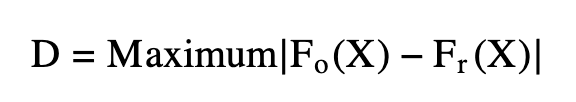

**F<sub>0</sub>(x)** = the total observed frequency distribution of a random sample

**F<sub>0</sub>(x) = <sup>k</sup>⁄<sub>n</sub>** where k = the number of observations and n is the total number of observations

**F<sub>r</sub>(x)** = the theoretical frequency distribution

If the calculated value is **less** than the critical value **D** we must **accept the null hypothesis**

If the calculated value is **greater** than the critical value we can **reject the null hypothesis**

### One-Sample Test

Let’s do an example! Say we are zoologists studying turtles. We want to conduct an experiment to see if different species of turtle prefer to eat cucumbers or lettuce when presented with both. We are going to use 5 different species and count how many turtles go for each food choice first in each population (n = 150).

```r
# create matrix with 5 columns and 2 rows
data <- matrix(c(16, 12, 1, 22, 11, 14, 18, 29, 8, 19), nrow = 2, ncol = 5, byrow = TRUE)
# specify the column names and row names of matrix
colnames(data) <- c('A.marmorata ','C.fimbriata ','C.picta ','C.flavomarginata ', 'C.amboinensis')
rownames(data) <-  c('Cucumber','Lettuce')
# assign to table
final = as.table(data)
# display
final
```

```
##          A.marmorata  C.fimbriata  C.picta  C.flavomarginata  C.amboinensis
## Cucumber           16           12        1                22            11
## Lettuce            14           18       29                 8            19
```

**H<sub>0</sub>** = There is no difference among turtle species with respect to their choice of cucumber over lettuce.

**H<sub>1</sub>** = There is a difference among turtle species with respect to their choice of cucumber over lettuce

Let’s say we predict 18 turtles from each species choose cucumber and make a new table with our prediction.

```r
#appending our original table
final_new <- final
#assigning a new row name and filling in the data using the list function
final_new <- rbind(final_new, 'Predictions' = list(18, 18, 18, 18, 18))
#ready to print!
final_new
```

```
##             A.marmorata  C.fimbriata  C.picta  C.flavomarginata  C.amboinensis
## Cucumber    16           12           1        22                11
## Lettuce     14           18           29       8                 19
## Predictions 18           18           18       18                18
```

```r
calculations <- matrix(c(16, 18, '16/150', '18/150', '2/150', 12, 18, '28/150', '36/150', '8/150', 1, 18, '29/150', '54/150', '25/150', 22, 18, '51/150', '72/150', '21/150', 11, 18, '62/150', '90/150', '28/150'), nrow = 5, ncol = 5, byrow = TRUE)
colnames(calculations) <- c('Observed ','Predictions ','F0(X)', 'Fr(X)', '|F0(X) -Fr(X)|')
rownames(calculations) <-  c('A.marmorata ','C.fimbriata ','C.picta ','C.flavomarginata ', 'C.amboinensis')
table = as.table(calculations)
table
```

```
##                   Observed  Predictions  F0(X)  Fr(X)  |F0(X) -Fr(X)|
## A.marmorata       16        18           16/150 18/150 2/150
## C.fimbriata       12        18           28/150 36/150 8/150
## C.picta           1         18           29/150 54/150 25/150
## C.flavomarginata  22        18           51/150 72/150 21/150
## C.amboinensis     11        18           62/150 90/150 28/150
```

Now it’s time to analyze! To find our critical D value we need to look at our table and find the maximum difference between F<sub>0</sub>(x) and F<sub>r</sub>(x). We can see that our maximum value is that of C. amboinensis at 28/150. Our critical D value that we will use to compare our values to is 0.1867. Now we can look at our table and choose a value of alpha to work with. Say we are 5% certain we are going to make a Type 1 error, i.e. detecting a difference under the assumption of the null, we can use our table to choose our critical value.

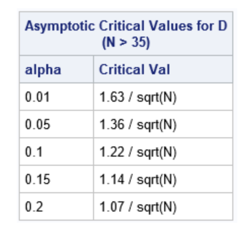

```r
#denote the total number of turtles
n <- 150
#grab our formula
D <- 1.36/sqrt(n)
#calculate!
D
```

```
## [1] 0.1110435
```

Our critical value for our data set at an alpha level of 5% is 0.11, which is smaller than our critical value of 0.1867. Because our value is **greater** than the critical value, we can reject the null and conclude that there is difference among turtle species with their respect to choosing cucumber over lettuce for their snack of choice!

## Challenge 1

Assuming an alpha level of 0.01, what is the critical D value for our sample? Can we still reject the null?

```r
#denote the total number of turtles
n <- 150
#grab our formula
D <- 1.63/sqrt(n)
#calculate!
D
```

```
## [1] 0.1330889
```

YES! 0.133 ≤ 0.1867, therefore we can still reject the null.

Now let’s do an example with a data set we are familiar with.

```r
#prep to curl our data
library(curl)
#curl our data
f <- curl("https://raw.githubusercontent.com/fuzzyatelin/fuzzyatelin.github.io/master/AN588_Fall23/zombies.csv")
#read our csv
z <- read.csv(f, header = TRUE, sep = ",", stringsAsFactors = TRUE)
#call our data set
head(z)
```

```
##   id first_name last_name gender   height   weight zombies_killed
## 1  1      Sarah    Little Female 62.88951 132.0872              2
## 2  2       Mark    Duncan   Male 67.80277 146.3753              5
## 3  3    Brandon     Perez   Male 72.12908 152.9370              1
## 4  4      Roger   Coleman   Male 66.78484 129.7418              5
## 5  5      Tammy    Powell Female 64.71832 132.4265              4
## 6  6    Anthony     Green   Male 71.24326 152.5246              1
##   years_of_education                           major      age
## 1                  1                medicine/nursing 17.64275
## 2                  3 criminal justice administration 22.58951
## 3                  1                       education 21.91276
## 4                  6                  energy studies 18.19058
## 5                  3                       logistics 21.10399
## 6                  4                  energy studies 21.48355
```

```r
#call our column of interest
age <- z$age
#use our function!
ks.test(age, "pnorm")
```

```
##
##  Asymptotic one-sample Kolmogorov-Smirnov test
##
## data:  age
## D = 1, p-value < 2.2e-16
## alternative hypothesis: two-sided
```

Our p-value is going to tell us if we can accept or reject the null, in this case, that the data we are working with is normally distributed. Since our value is < 0.05 we can reject the null and say that our data is not normally distributed.

```r
#denote the total number of turtles
n <- 1001
#grab our formula
D <- 1.63/sqrt(n)
#calculate!
D
```

```
## [1] 0.05151937
```

Our calculated value of D is 0.05 which is smaller than our critical value of 1. This also makes sense, and confirms our ability to reject the null.

Now let’s do a two-sample test.

First let’s make two data sets, one random, and one normal.

```r
#make this example reproducible
set.seed(0)
#generate two data sets. We are using rpois() to ensure a non-normal distribution, and rnorm() to ensure a normalized one.
data1 <- rpois(n=50, lambda=5)
data2 <- rnorm(100)
```

```r
#using our function, we are going to fill both arguments with the data sets to ensure a comparison
ks.test(data1, data2)
```

```
##
##  Exact two-sample Kolmogorov-Smirnov test
##
## data:  data1 and data2
## D = 0.95, p-value < 2.2e-16
## alternative hypothesis: two-sided
```

Now we can look at both our D value and p-value. Our p-value is < 0.05 and therefore allows us to reject the null. Our data sets come from two different distributions, which is what we expected since we made them that way! Our D value is 0.95, going back to our previous table we can pick an alpha value of 0.05.

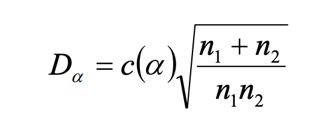

```r
#denote the total number of turtles
n12 <- (150 + 50)/(150*50)
#grab our formula
n12 <- sqrt(n12)
#calculate!
D <- n12*0.05
D
```

```
## [1] 0.008164966
```

If you’re curious about seeing a KS Test in action, feel free to check out this paper on same-sex sexual behavior in termites.

## Sources

https://www.tutorialspoint.com/statistics/kolmogorov_smirnov_test.htm  
https://towardsdatascience.com/understanding-kolmogorov-smirnov-ks-tests-for-data-drift-on-profiled-data-5c8317796f78  
https://www.itl.nist.gov/div898/handbook/eda/section3/eda35g.htm  
https://www.researchgate.net/post/Interpret_P_and_D_values_in_Two-Sample_Kolmogorov-Smirnov_Test  
https://www.statisticshowto.com/kolmogorov-smirnov-test/  
https://blogs.sas.com/content/iml/2019/05/15/kolmogorov-d-statistic.html  
https://www.sciencedirect.com/topics/earth-and-planetary-sciences/kolmogorov-smirnov-test  
https://stat.ethz.ch/R-manual/R-devel/library/stats/html/ks.test.html  
https://www.statology.org/kolmogorov-smirnov-test-r/